# Enrichment

2023-01-31

## Enrichment analyses

Different enrichment databases exist, and different R-tools exist to utilize such enrichment databases. Here I will show some of the ones I like.

We will use the t-test data I created in chapter 4. To showcase enrichments, I will use the UNADJUSTED p-value, to increase the number of significant proteins. Of course, this is not the best way to do it, but it makes it easy for me to show what one can do in R :).

### Libraries and Import

```r
library(tidyverse)
library(clusterProfiler)
```

```r
library(ggraph)
library(org.Hs.eg.db)
library(WebGestaltR)
library(ReactomePA)
library(enrichplot)
library(msigdbr)

ttest_results <- read.csv("ttest_results.csv")
```

### ClusterProfiler

Clusteprofiler is an enrichment package from a yu-lab at Jinan University (China). Its a great package because you can do the following things all in one:

- Do enrichments using GO, KEGG, Reactome, msgiDB
- Multitude of vizualizations

For more ideas of vizualization, visit: https://yulab-smu.top/biomedical-knowledge-mining-book/enrichplot.html

#### GO - Without Fold Change

Also commonly called over representation analysis (ORA) we take our significant proteins and enrich for these. When working with a relative small number of proteins such as when working with plasma, its good to use a background. When you have 10k proteins, its of less importance. Long story short; try both out.

I turn it off because otherwise there was nothing significant in this dataset.

```r
#Convert GENE name to ENTREZ ID
#The package needs ENTREZID, so we need to change that...
ttest_results <- ttest_results %>%

  #We also create a column to determine if protein went up or down. We get to this in the next chapter
  mutate(Direction = ifelse(estimate < 0, "down", "up")) %>%

  #Forcing it to become characters is important, otherwise it bugs.
  mutate(entrezID =  as.character(mapIds(org.Hs.eg.db, ttest_results$Gene, "ENTREZID", "SYMBOL")))
#Get the significant proteins
significant_ttest <- ttest_results %>%
  filter(p < 0.05)


#Run the Enrichment analysis
ttest_ORA_GO_BP <- enrichGO(
  gene=significant_ttest$entrezID, #Put your significant protein

  #THIS IS WHERE YOU PUT THE BACKGROUND, SO ALL ENTREZID's
  #universe = ttest_results$entrezID,

  #You can select which GO term to search for: BP, CC or MF
  ont="BP",

  #Some standard settings

  pvalueCutoff=0.05,
  OrgDb = "org.Hs.eg.db", #for GO only
  pAdjustMethod = "BH",
  qvalueCutoff = 0.05
)

#You can view the results by running the line below (un-comment it)
# View(ttest_ORA_GO_BP@result)
```

Visualization using Dots

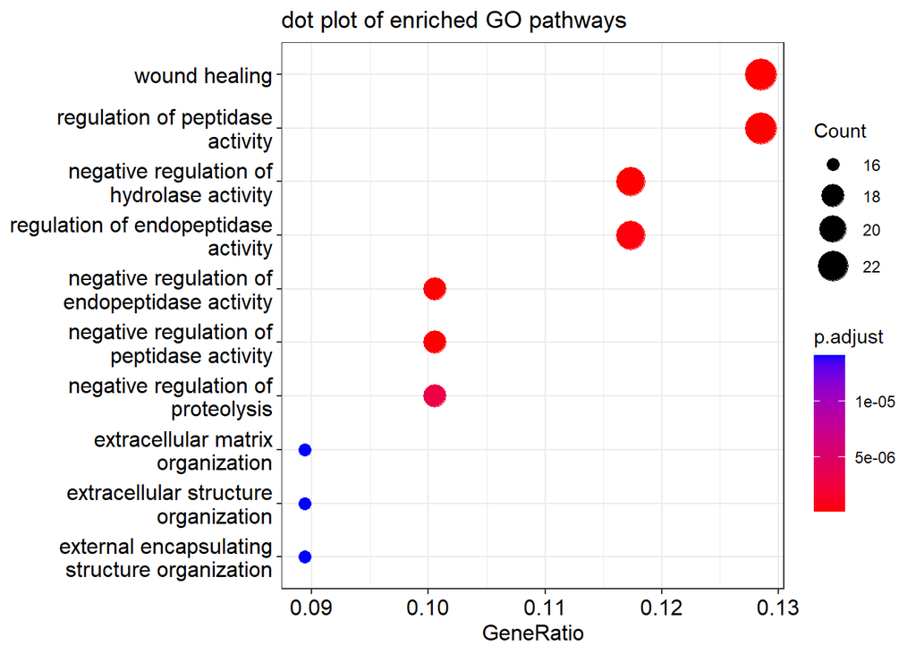

```r
dotplot(
  ttest_ORA_GO_BP,
  showCategory = 10,
  title = "dot plot of enriched GO pathways"
  )
```

Gene Network

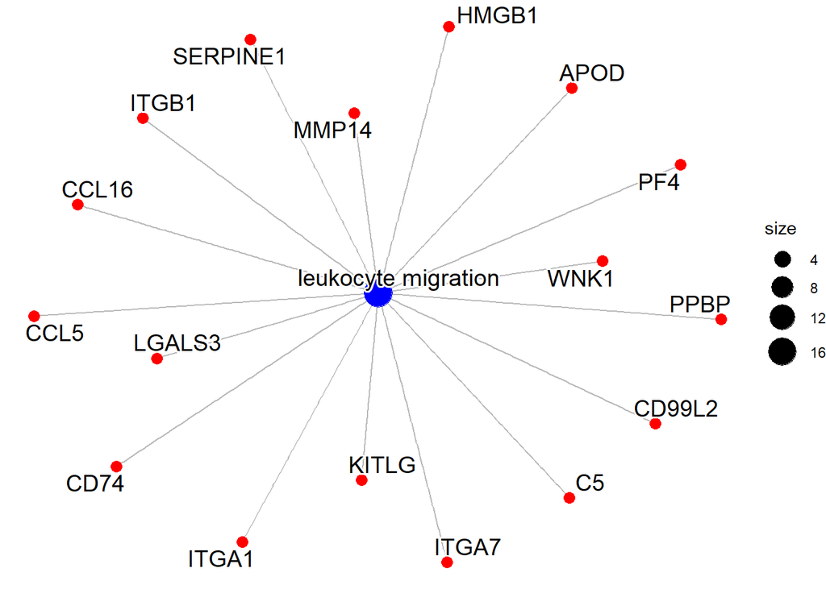

```r
#This step we do to bring back the gene-names. If you dont do it, you will get numbers instead of gene-names
ttest_ORA_GO_BP_readable <- setReadable(ttest_ORA_GO_BP, 'org.Hs.eg.db', "ENTREZID")

#plot, there's a few variables you can play with.
cnetplot(
  ttest_ORA_GO_BP_readable,
  showCategory = "leukocyte migration", # INSTEAD YOU CAN PUT A NUMBER AND IT WILL DO THE TOP-X.
  color_gene = "red",
  color_category = "blue"
         )
```

Enrichment maps. These do not show unique proteins but instead it plots enrichments that pair together (based on the gene-hits in them).

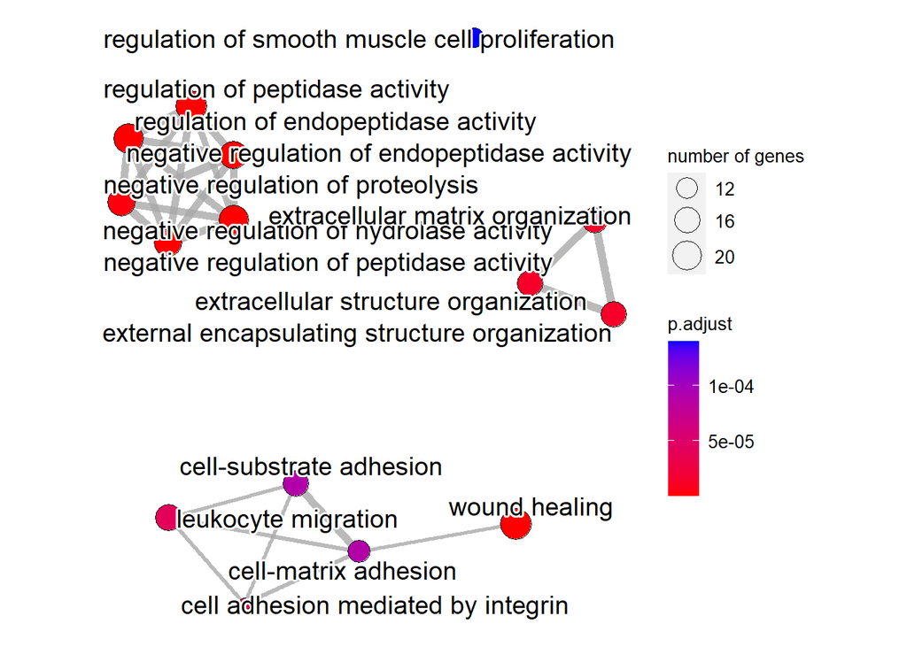

```r
#You need to run this first. It pairs enrichments together through some scoring mechanism
ttest_ORA_GO_BP_pairwised <- pairwise_termsim(ttest_ORA_GO_BP)


#Plot
emapplot(
  ttest_ORA_GO_BP_pairwised,
  showCategory = 15, #TopX you want to include
  )
```

#### GO - Up and Down Split

In some cases, you might want to do a separate enrichment for the proteins that went up and down. This can give some additional insights.

```r
#Create the enrichment again
ttest_ORA_GO_BP_direction <- compareCluster(
  entrezID ~ Direction,
  data=significant_ttest,
  fun = enrichGO,
  pvalueCutoff=0.05,
  OrgDb = "org.Hs.eg.db", #for GO only
  ont="BP",               #for GO only "CC" "MF" , "BP"
  readable = TRUE,
  pAdjustMethod = "BH",
  qvalueCutoff = 0.05
)
```

Plot for the up and down regulated proteins. As you can see, it indicates where the enrichment only comes from up regulat, downregulated or a mix of both.

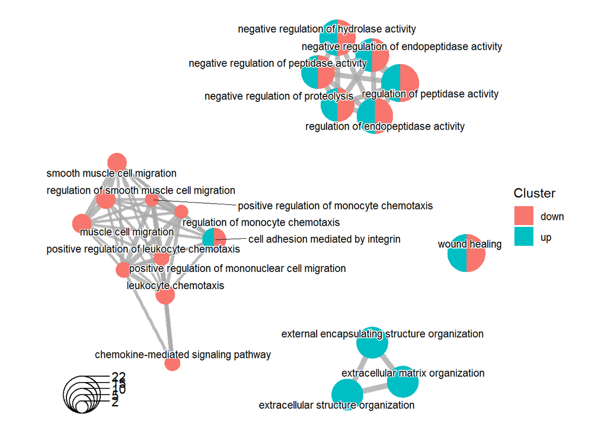

```r
ttest_ORA_GO_BP_direction_pairwise <- pairwise_termsim(ttest_ORA_GO_BP_direction)

#Plot
emapplot(ttest_ORA_GO_BP_direction_pairwise,
         showCategory = 10)
```

#### GO - GSEA

An alternative way to enrich is gene set enrichment analysis (GSEA). Instead of only taking significant proteins, you instead take ALL proteins in your data frame and use an additional score for the enrichment. Commonly, we take a -log10 of the pvalue. Next, we multiply that value by -1 if it was down regulated, this way we also include the direction of the protein, which is required for GSEA.

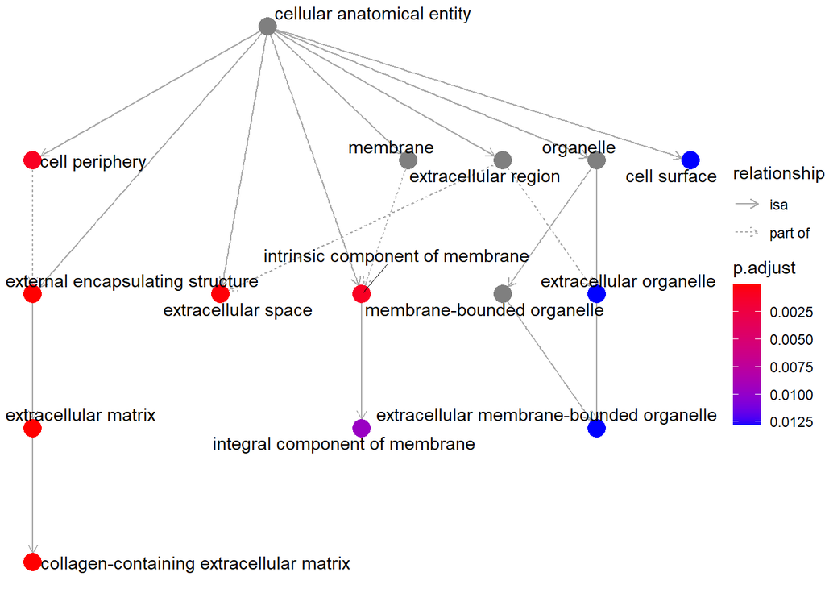

```r
#prepare data for GSEA
ttest_results_gsea <- ttest_results %>%

  #Forcing it to become characters is important, otherwise it bugs.
  mutate(entrezID =  as.character(mapIds(org.Hs.eg.db, ttest_results$Gene, "ENTREZID", "SYMBOL"))) %>%

  #Apply the -log10
  mutate(gseaColumn = -1*log10(p)) %>%

  #add the directionallity
  mutate(gseaColumn = ifelse(estimate < 0, gseaColumn * -1, gseaColumn)) %>%

  #Finally, we MUST RANK ORDER THE PROTEINS BASED ON THAT NEW COLUMN WITH HIGHEST VALUE ON TOP!
  dplyr::arrange(-gseaColumn) #minus to force highest on top.
#GSEA analysis wants a named list as input. Its a bit confusing, but we gotta roll with it.
gsea_genelist <- ttest_results_gsea$gseaColumn
names(gsea_genelist) <- ttest_results_gsea$entrezID

#RUN THE ENRICHMENT
ttest_gsea_GO_BP <-
  gseGO(
    geneList = gsea_genelist,
    ont="CC",               #for GO only "CC" "MF" , "BP"

    #Standard settings.
    minGSSize = 100,
    maxGSSize = 500,
    verbose = F,
    pvalueCutoff=0.05,
    OrgDb = org.Hs.eg.db #for GO only
  )
goplot(ttest_gsea_GO_BP)
```

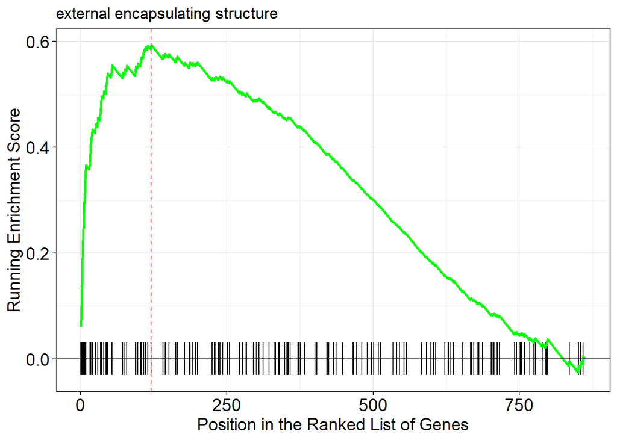

```r
#If you want to plot a specific GSEA ranking, you can select them numeric...
gseaplot(ttest_gsea_GO_BP, geneSetID = 1, by = "runningScore", title = ttest_gsea_GO_BP$Description[1])
```

#### KEGG Example

We use same package just slighly different function to do KEGG analysis.

```r
#Convert GENE name to ENTREZ ID
#The package needs ENTREZID, so we need to change that...
ttest_results <- ttest_results %>%

  #We also create a column to determine if protein went up or down. We get to this in the next chapter
  mutate(Direction = ifelse(estimate < 0, "down", "up")) %>%

  #Forcing it to become characters is important, otherwise it bugs.
  mutate(entrezID =  as.character(mapIds(org.Hs.eg.db, ttest_results$Gene, "ENTREZID", "SYMBOL")))
#Get the significant proteins
significant_ttest <- ttest_results %>%
  filter(p < 0.05)


#Run the Enrichment analysis
ttest_ORA_KEGG <- enrichKEGG(
  gene=significant_ttest$entrezID, #Put your significant protein

  #THIS IS WHERE YOU PUT THE BACKGROUND, SO ALL ENTREZID's
  #universe = ttest_results$entrezID,

  #You need to specify the organism. this is the KEGG identifier
  organism = "hsa",

  #Some standard settings
  pvalueCutoff=0.05,
  pAdjustMethod = "BH",
  qvalueCutoff = 0.05
)
```

```
## Reading KEGG annotation online:
```

```
## Reading KEGG annotation online:
```

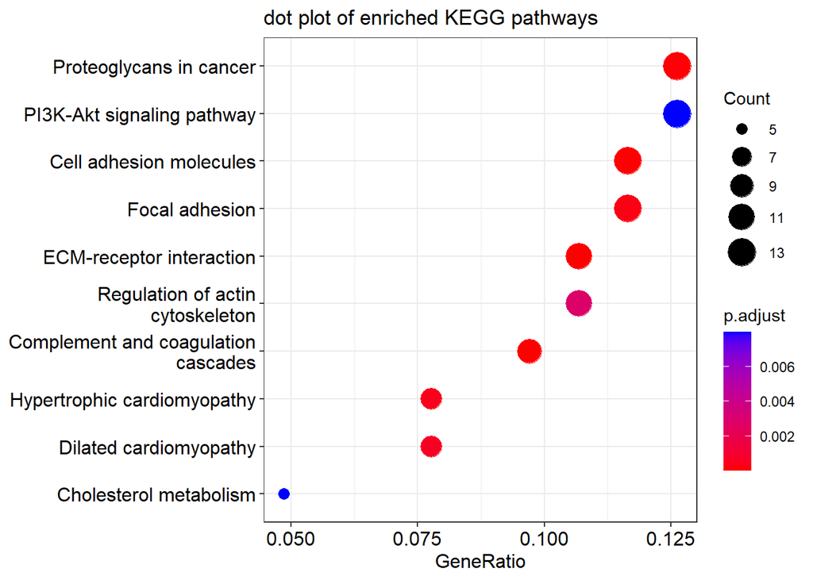

```r
#You can use same vizualizations as for GO
dotplot(
  ttest_ORA_KEGG,
  showCategory = 10,
  title = "dot plot of enriched KEGG pathways"
  )
```

### MSGiDB - HALLMARK and more

MSGiDB is a database by the broad institute which includes a lot, such as the specific HALLMARK pathways. They can be nice to give a shot, check out there website which subpart (or all) you want to test for.

http://www.gsea-msigdb.org/gsea/msigdb/collections.jsp

#### Run Hallmark analysis

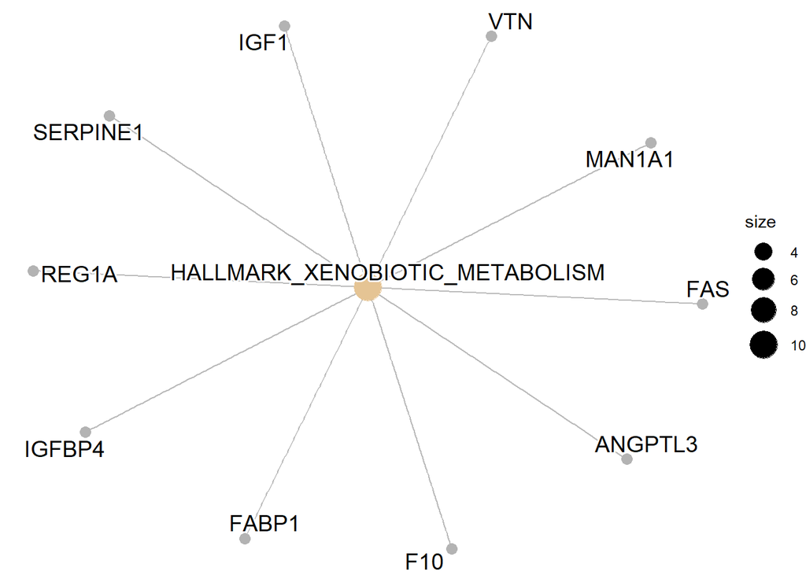

```r
#Set the msgidb. We specify HALLMARK, but you can select any (or all by not specifying any) from the weblink above
all_gene_sets = msigdbr(species = "Homo sapiens", category = "H")
msigdbr_t2g = all_gene_sets %>%
  dplyr::distinct(gs_name, gene_symbol) %>%
  #mutate(gs_name = str_remove_all(gs_name, "HALLMARK_")) %>% #REMOVE ALL THE HALLMARK STUFF
  as.data.frame()

#Convert GENE name to ENTREZ ID
#The package needs ENTREZID, so we need to change that...
ttest_results_hallmark <- ttest_results %>%

  #We also create a column to determine if protein went up or down. We get to this in the next chapter
  mutate(Direction = ifelse(estimate < 0, "down", "up"))


#Get the significant proteins
significant_ttest_hallmark <- ttest_results_hallmark %>%
  filter(p < 0.05)

#If you want to use a background, do the following
#BACKGROUND SEEMS TO BE PRETTY STRICT --> NO HITS!
Background <- data.frame(ttest_results_hallmark$Gene)
colnames(Background) <- "background"

hallmark_enrichments <- enricher(
  gene = significant_ttest_hallmark$Gene,
  #universe = Background$background,
  TERM2GENE = msigdbr_t2g
)

#View Results
#View(hallmark_enrichments@result)

#We can again use some of the Clusteprofiler tools to visualize
cnetplot(
  hallmark_enrichments,
  showCategory = "HALLMARK_XENOBIOTIC_METABOLISM" #select one by looking at the DF
         )
```